# Three Logicians Walk Into a Bar

# Intro

### The Joke

*Three logicians walk into a bar. The bartender asks, “Do you all want a beer?”*

#### But First… A Lower-Level Scrutiny

Before examining the canonical form of this joke, it’s worthwhile to examine a simpler form. Some components of the joke are more easily understood without the full, distracting complexity of the canonical form. Consider:

*A logician walks into a bar. The bartender asks, “Do you want a beer?”*

- *Ada: “Yes!”*

This is not funny, but it highlights this fact: Ada might not want a beer, and so the “punchline” could be

- *Ada: “No”*

Here’s the entirety of this “joke” in a single plot:

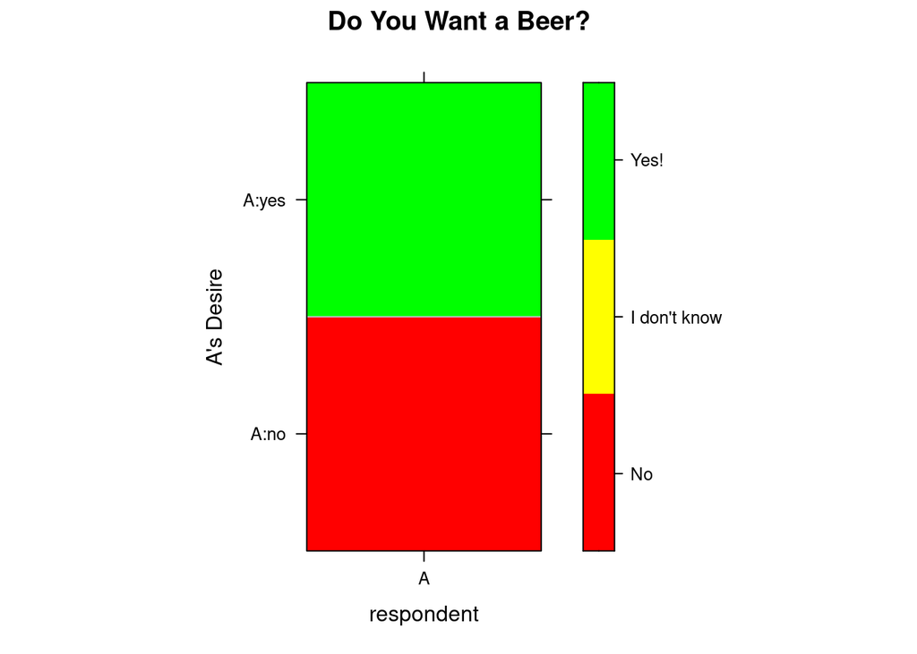

#### Generalizing a bit…

Our bartender could ask a different question: “Do you not want a beer”? And to be really complete, there are two more questions: 1) “Is 1 equal to 1?” and 2) “Is 1 equal to 0?”. Despite our logician’s desire for a beer (or not), I am confident she will respect the bartender with a correct answer.

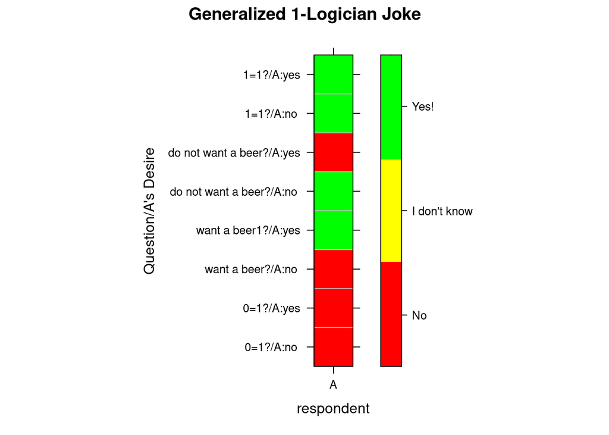

#### Generalizing a bit…

If we add one more logician, a new outcome appears: uncertainty. The basic form of the joke is “do you both want a beer?”, with this outcome:

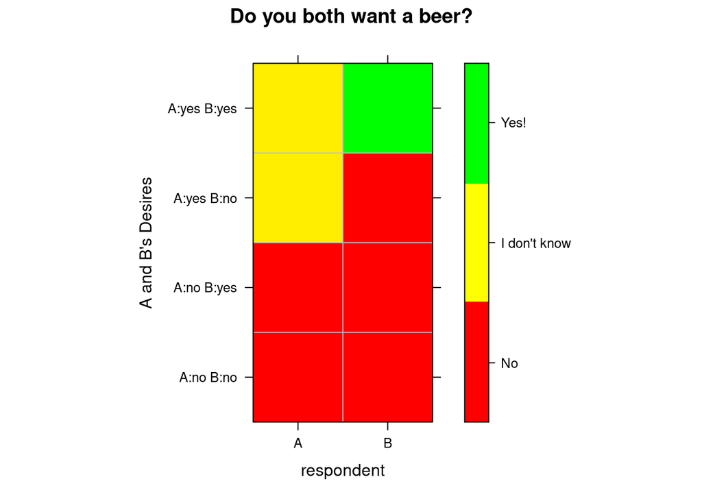

> How to read this chart: choose a row, for example the top row (“A:yes B:yes”). In this case A and B both want a beer. Their replies are in the grid, left to right: for the top row, the answers are “A: I don’t know; B: Yes!”).

With two logicians, I think we have enough complexity to see that humor could arise here, though not enough to definitely have humor.

#### Generalizing a bit…

How many questions can the bartender ask of two logicians? Any logician will know this at a young age, and I think you can find the answer online, spoiler alert, it’s $2^{2^{2}} = 16$. Here’s how to see it: imagine a template for a 2-input logic function, like so:

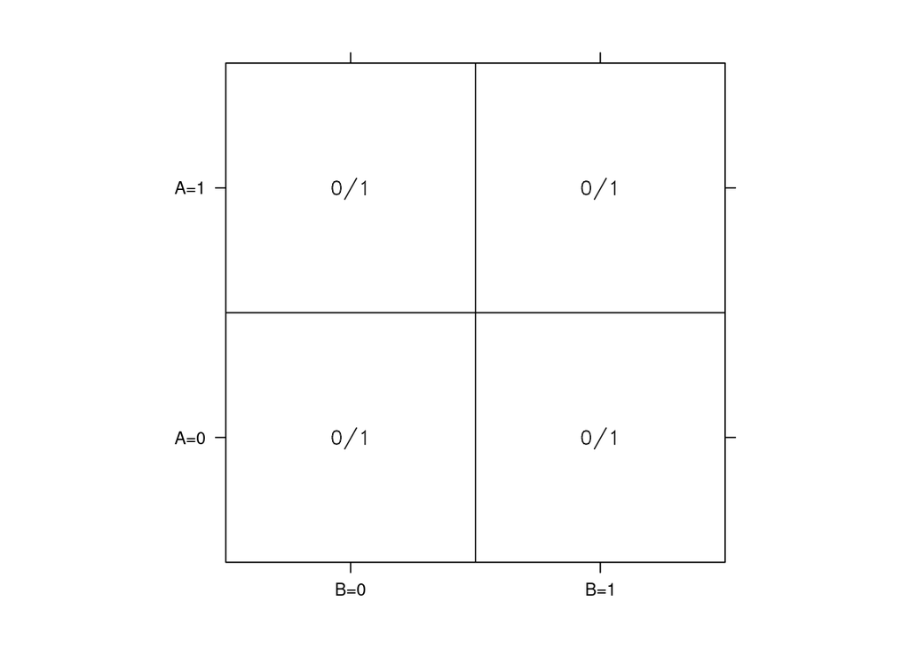

There are $2^2 = 4$ squares in the grid, for each possible combination of A and B. And each of the of the squares can be 0 or 1, so that’s $2^4 = 16$ total possible functions. Voila!

#### A Function-Identification Convention

Some of the 16 functions of 2 inputs have names, like “AND” and “OR”. And there are less common function names, like “NAND” and “XNOR”. Some functions don’t have particular names, and have to be laboriously described, like “A and not B”. It will be handy to have a general convention for identifying the functions. Here’s one convention: apply a weighting value to each of the 4 squares, like so:

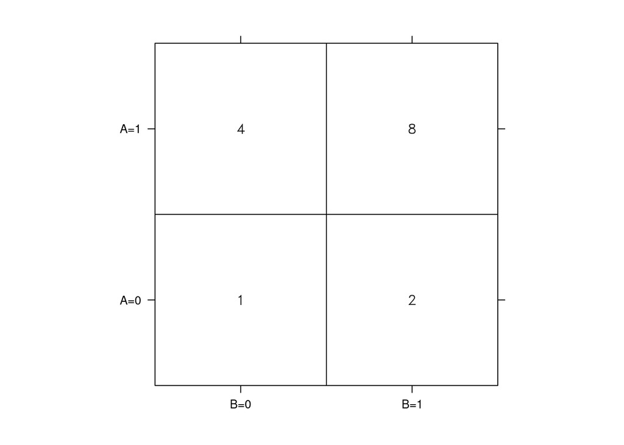

A particular function has either ‘0’ or ‘1’ in each square. Adding up all the weights for squares where the value is ‘1’ gives a unique index for the function.

Examples:

```
AND has a '1' only for A=1, B=1, weighting value 8, so its index is 8
OR has a '1' in three squares, index is 14
A and not B has index 4
```

There are an infinite number of other conventions for creating unique indices for each of the 16 functions, for example instead of {1, 2, 4, 8} we can choose any four prime numbers. But I think the {1, 2, 4, 8} convention is tidy.

### 2-Logician Completeness

Here is a plot of all of the 2-logician jokes. Find a particular joke in the grid by adding up the row and column indices. The 4x2 block within the grid represents the joke responses.

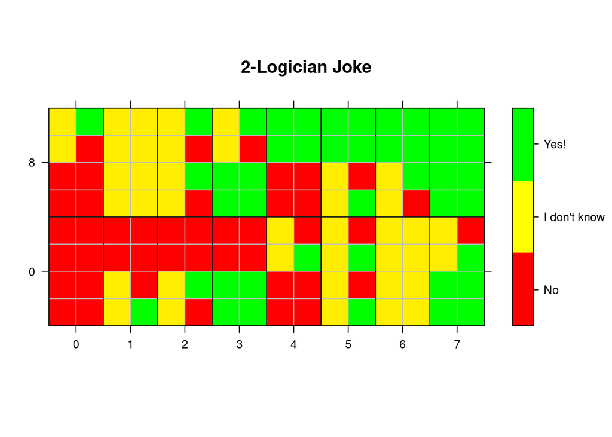

### The Full Joke

- *Ada: “I don’t know”*
- *Bertrand: “I don’t know”*
- *Claude: “Yes!”*

### Explanation

How does this work? Each logician really does want a beer, but doesn’t know what the others want. If the bartender’s question is taken literally (“do **all** of you want a beer), no logician knows the answer - at first. (On other hand, if any of the logicians didn’t want a beer, he or she could answer,”no”.) After Ada and Bertrand give their “I don’t know” answers (thus - they do want a beer), Claude can give a definite answer.

### Generalizations

#### Forms of the Joke

There are other forms of this joke, depending on the bartender’s question. An alternative, equally funny, but less jolly form of the joke is:

*Three logicians walk into a bar. The bartender asks, “do any of you want a beer?”*

- *A: “I don’t know”*
- *B: “I don’t know”*
- *C: “No!”*

In this case, no one wanted a beer, but again only Claude was able to answer the bartender.

Here’s a third form of the joke:

*Three logicians walk into a bar. The bartender asks, “do an odd number of you want a beer?”*

- *A: “I don’t know”*
- *B: “I don’t know”*
- *C: “I don’t know!”*

So funny!

#### Counting the Jokes

The bartender could also ask some less bartenderly questions, like “does A want a beer, and does B not want a beer, and does C want a beer?” How many bartender questions are there? Well… 256.

To see why, consider this plot of the first question, “do you all want a beer”? The plot shows the final answer, if all logicians’ desires were known.

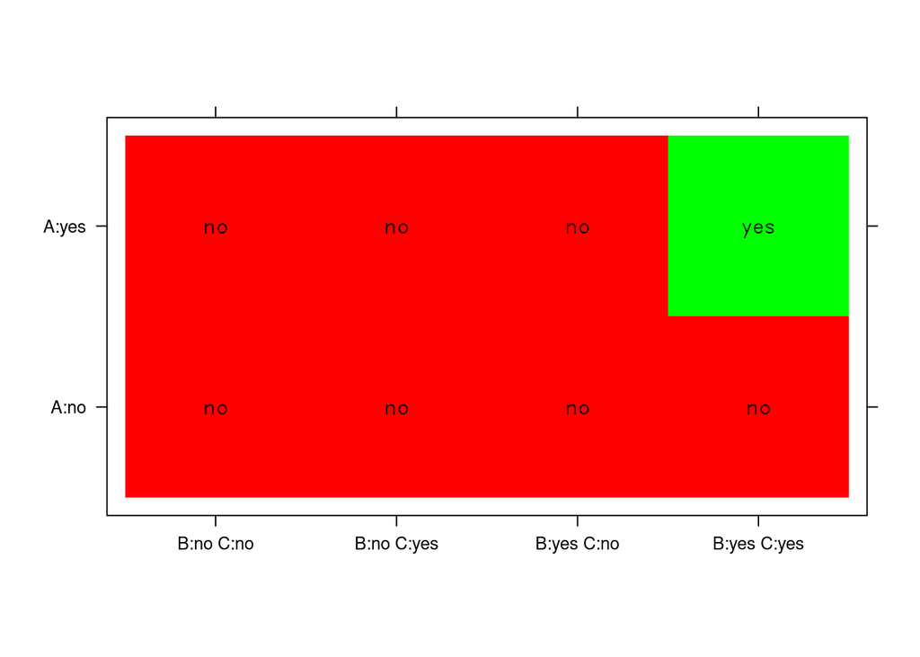

And here’s “do any of you want a beer?”:

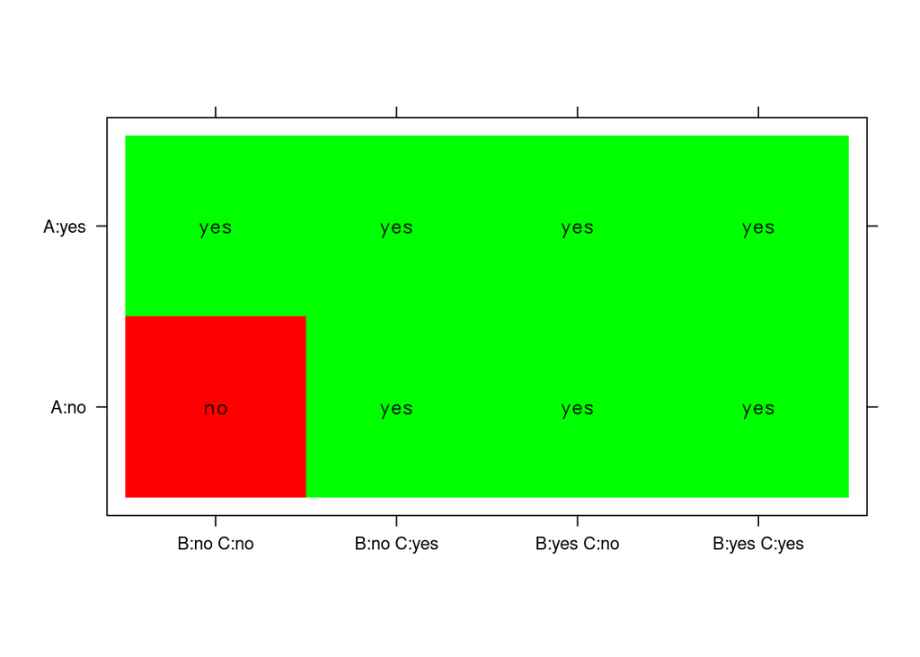

Last example, “do an odd number of you want a beer?”:

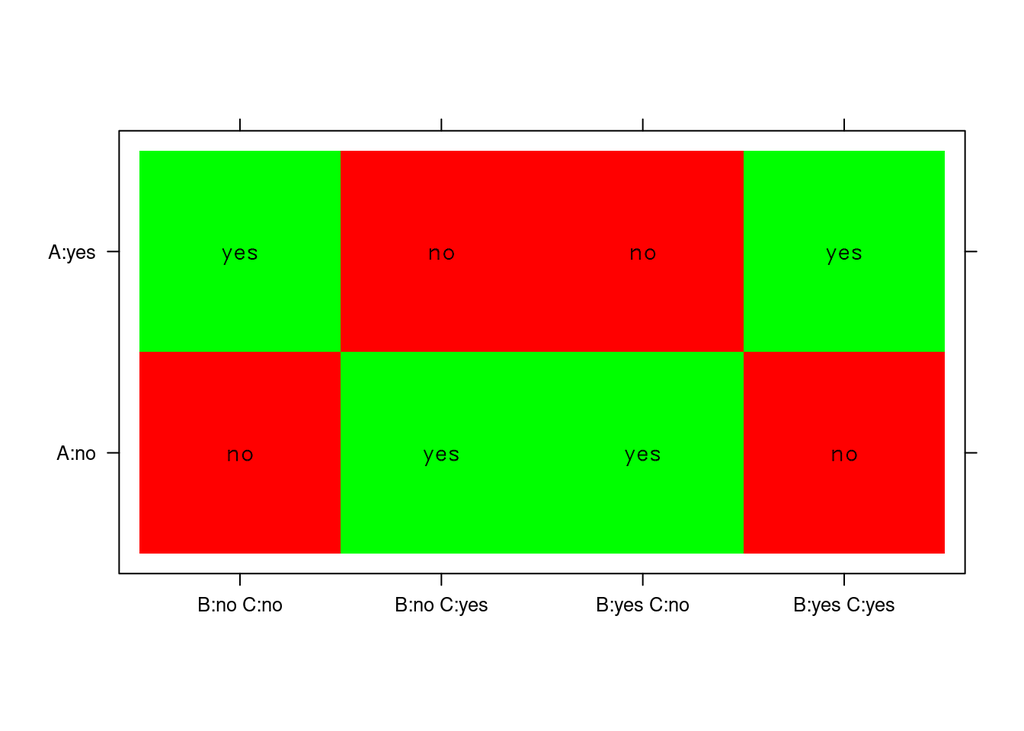

Each arrangement of the plot has 8 squares that can be “yes” or “no”. So the number of questions is $2^{8} = 256$.

#### Effect of the Need for Beer

Our three logicians may or may not want a beer; 3 logicians and 2 options means there are ${2}^{3}$ = 8 ways the joke could unfold. But! Some of these outcomes are identical. For example, if it’s “do you all want a beer?” and A doesn’t want a beer, the answers are “no”, “no”, and “no”, no matter what B and C want. If A wants a beer but B doesn’t, the answers are “I don’t know”, “no”, and “no”, even if C wants a beer.

Here’s a plot showing all 8 possible joke outcomes.

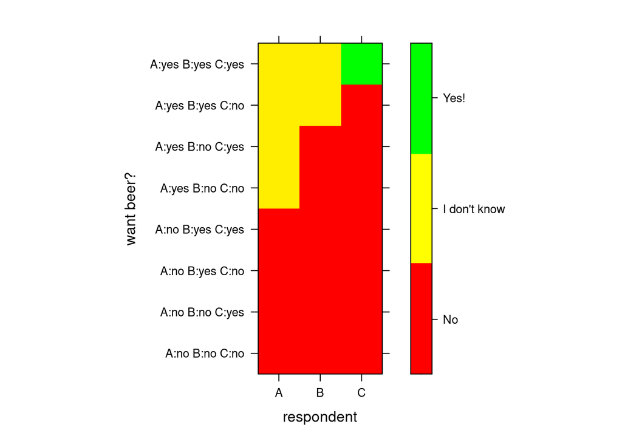

#### Interlude: Notation

Each of the 256 bartender questions can be assigned an index, from 0 to 255. Here’s one way to make the assignments: assign a value to each of the 8 cells of the plot; the function’s index value is the sum of all cell values where the function output is “yes”:

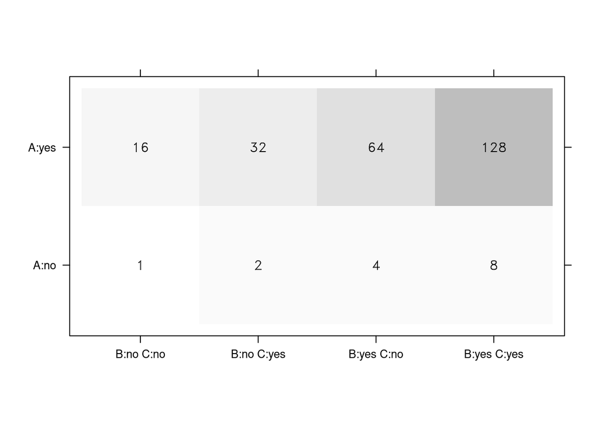

The bartender question, “do you all want a beer” is the one with index 128; for shorthand let’s call it $j_{128}$. Likewise, “do any of you want a beer” is $j_{254}$, “do an odd number of you want a beer”: $j_{150}$.

The logicians’ beer/no-beer choice is 1 for beer, 0 for no-beer, and there are three of them, so we can use a triplet of 0/1 to show what they want. We can encode the answer as”I don’t know” $\mapsto$ $X$, “no” $\mapsto$ $0$, “yes” $\mapsto$ $1$. Putting it all together, the first form the joke above is
$$j_{128}(1, 1, 1)
= \{X, X, 1\}$$

The other 7 outcomes of this form of the joke are:
$$j_{128}(0, 0, 0) = \{0, 0, 0\}$$
$$j_{128}(0, 0, 1) = \{0, 0, 0\}$$
$$j_{128}(0, 1, 0) = \{0, 0, 0\}$$
$$j_{128}(0, 1, 1) = \{0, 0, 0\}$$
$$j_{128}(1, 0, 0) = \{X, 0, 0\}$$
$$j_{128}(1, 0, 1) = \{X, 0, 0\}$$
$$j_{128}(1, 1, 0) = \{X, X, 0\}$$
The number of different ways $j_{128}$ can be answered, $N_{128}$, is 4: $\{0, 0, 0\}, \{X, 0, 0\}, \{X, X, 0\}, \{X, X, 1\}$.